# Covid19 Analysis of Austria by Using R

Azeem Khadam

October 2021

## The package Tidyverse

In this file we are going to analyse the Covid19 in Austria by using the statistical programming language [R](https://www.r-project.org/). In particular we use the package `tidyverse`. [Tidyverse](https://www.tidyverse.org/) is a package of packages of R that are designed to work well together. First, here we activate `tidyverse` by using the `library` function. Since it is already installed in our system, otherwise we have to use the function `install.packages()` in order to install it first.

```r
library(tidyverse)
```

## Loading the data set

Now we load the data set. We specifically use the package `readr` and its function `read_csv2`. Note that in German notation, a comma `,` is used to separate the decimal part of a (rational) number (not the dot `.`). So the delimiter used by `csv` files is the semicolon `;` (not the usual `,`) and to read such a `csv` file the function `read_csv2` works perfectly well. Note that the function `read_csv` works for those `csv` files having dot `.` as a delimiter.

```r
covid <- read_csv2("CovidFaelle_Timeline.csv", col_types = cols(Time=col_date("%d.%m.%Y %H:%M:%S " )) )
```

```
## i Using "','" as decimal and "'.'" as grouping mark. Use `read_delim()` for more control.
```

**Note:** The source of data is the dashboard of [Austrian Agency of Health and Food Security](https://covid19-dashboard.ages.at).

*Moreover, we are using the data uploaded on October 02, 2021.*

## Dive into analysis…

Let us look at the data table (which is in fact a `tibble`). Note that one of the advantage of having a `tibble` is that it shows us the dimension of the table as well as the data types of all the columns.

```r
covid
```

```
## # A tibble: 5,840 x 12
##    Time       Bundesland       BundeslandID AnzEinwohner AnzahlFaelle AnzahlFaelleSum
##    <date>     <chr>                   <dbl>        <dbl>        <dbl>           <dbl>
##  1 2020-02-26 Burgenland                  1       296010            0               0
##  2 2020-02-26 Kärnten                     2       562089            0               0
##  3 2020-02-26 Niederösterreich            3      1690879            0               0
##  4 2020-02-26 Oberösterreich              4      1495608            0               0
##  5 2020-02-26 Salzburg                    5       560710            0               0
##  6 2020-02-26 Steiermark                  6      1247077            0               0
##  7 2020-02-26 Tirol                       7       760105            0               0
##  8 2020-02-26 Vorarlberg                  8       399237            0               0
##  9 2020-02-26 Wien                        9      1920949            1               1
## 10 2020-02-26 Österreich                 10      8932664            1               1
## # ... with 5,830 more rows, and 6 more variables: AnzahlFaelle7Tage <dbl>,
## #   SiebenTageInzidenzFaelle <dbl>, AnzahlTotTaeglich <dbl>,
## #   AnzahlTotSum <dbl>, AnzahlGeheiltTaeglich <dbl>, AnzahlGeheiltSum <dbl>
```

There are 12 columns in the table. Also, the above output shows us the first 10 rows of the data set. It is a data of February 26, 2020 and first 9 rows correspond to each State of Austria and the 10th row corresponds to Austria. We can even look at first 15 rows by using the function `head` and specifying number of rows by using the argument `n`.

```r
head(covid, n=15)
```

```
## # A tibble: 15 x 12
##    Time       Bundesland       BundeslandID AnzEinwohner AnzahlFaelle AnzahlFaelleSum
##    <date>     <chr>                   <dbl>        <dbl>        <dbl>           <dbl>
##  1 2020-02-26 Burgenland                  1       296010            0               0
##  2 2020-02-26 Kärnten                     2       562089            0               0
##  3 2020-02-26 Niederösterreich            3      1690879            0               0
##  4 2020-02-26 Oberösterreich              4      1495608            0               0
##  5 2020-02-26 Salzburg                    5       560710            0               0
##  6 2020-02-26 Steiermark                  6      1247077            0               0
##  7 2020-02-26 Tirol                       7       760105            0               0
##  8 2020-02-26 Vorarlberg                  8       399237            0               0
##  9 2020-02-26 Wien                        9      1920949            1               1
## 10 2020-02-26 Österreich                 10      8932664            1               1
## 11 2020-02-27 Burgenland                  1       296010            0               0
## 12 2020-02-27 Kärnten                     2       562089            0               0
## 13 2020-02-27 Niederösterreich            3      1690879            0               0
## 14 2020-02-27 Oberösterreich              4      1495608            0               0
## 15 2020-02-27 Salzburg                    5       560710            0               0
## # ... with 6 more variables: AnzahlFaelle7Tage <dbl>,
## #   SiebenTageInzidenzFaelle <dbl>, AnzahlTotTaeglich <dbl>,
## #   AnzahlTotSum <dbl>, AnzahlGeheiltTaeglich <dbl>, AnzahlGeheiltSum <dbl>
```

So the the rows from 11 to 15 are from 27.02.2020. This means the last 10 rows must be from today’s data (hopefully!).

```r
tail(covid, n=10)
```

```
## # A tibble: 10 x 12
##    Time       Bundesland       BundeslandID AnzEinwohner AnzahlFaelle AnzahlFaelleSum
##    <date>     <chr>                   <dbl>        <dbl>        <dbl>           <dbl>
##  1 2021-10-01 Burgenland                  1       296010           49           20024
##  2 2021-10-01 Kärnten                     2       562089           88           44617
##  3 2021-10-01 Niederösterreich            3      1690879          272          123364
##  4 2021-10-01 Oberösterreich              4      1495608          470          137089
##  5 2021-10-01 Salzburg                    5       560710          153           57536
##  6 2021-10-01 Steiermark                  6      1247077          272           90458
##  7 2021-10-01 Tirol                       7       760105          112           69813
##  8 2021-10-01 Vorarlberg                  8       399237           52           34209
##  9 2021-10-01 Wien                        9      1920949          443          166240
## 10 2021-10-01 Österreich                 10      8932664         1911          743350
## # ... with 6 more variables: AnzahlFaelle7Tage <dbl>,
## #   SiebenTageInzidenzFaelle <dbl>, AnzahlTotTaeglich <dbl>,
## #   AnzahlTotSum <dbl>, AnzahlGeheiltTaeglich <dbl>, AnzahlGeheiltSum <dbl>
```

Why not to transform the names of columns into English, so that our non-German readers can also understand what is going on? :)

Let us first see the names of all columns, and then translate them into English (we will also lower all the cases). This we do by using the function `rename` from the package `dplyr`.

```r
colnames(covid)
```

```
##  [1] "Time"                     "Bundesland"
##  [3] "BundeslandID"             "AnzEinwohner"
##  [5] "AnzahlFaelle"             "AnzahlFaelleSum"
##  [7] "AnzahlFaelle7Tage"        "SiebenTageInzidenzFaelle"
##  [9] "AnzahlTotTaeglich"        "AnzahlTotSum"
## [11] "AnzahlGeheiltTaeglich"    "AnzahlGeheiltSum"
```

```r
covid <- rename(covid, time = Time, state = Bundesland, stateID = BundeslandID, number_residents = AnzEinwohner,
       number_cases = AnzahlFaelle, total_number_cases = AnzahlFaelleSum, seven_days_number_cases = AnzahlFaelle7Tage, seven_days_incidence = SiebenTageInzidenzFaelle, daily_deaths = AnzahlTotTaeglich,
       total_deaths = AnzahlTotSum, daily_recovered = AnzahlGeheiltTaeglich, total_recovered = AnzahlGeheiltSum )

colnames(covid)
```

```
##  [1] "time"                    "state"
##  [3] "stateID"                 "number_residents"
##  [5] "number_cases"            "total_number_cases"
##  [7] "seven_days_number_cases" "seven_days_incidence"
##  [9] "daily_deaths"            "total_deaths"
## [11] "daily_recovered"         "total_recovered"
```

We now use `filter` function from `dplyr` to filter the data for whole of Austria (note that Austria’s ID is 10).

```r
covid_austria <- filter(covid, stateID == 10)

tail(covid_austria, n = 10)
```

```
## # A tibble: 10 x 12
##    time       state      stateID number_residents number_cases total_number_cas~
##    <date>     <chr>        <dbl>            <dbl>        <dbl>             <dbl>
##  1 2021-09-22 Österreich      10          8932664         1847            727015
##  2 2021-09-23 Österreich      10          8932664         1829            728844
##  3 2021-09-24 Österreich      10          8932664         1839            730683
##  4 2021-09-25 Österreich      10          8932664         1395            732078
##  5 2021-09-26 Österreich      10          8932664         1395            733473
##  6 2021-09-27 Österreich      10          8932664         1592            735065
##  7 2021-09-28 Österreich      10          8932664         2642            737707
##  8 2021-09-29 Österreich      10          8932664         1954            739661
##  9 2021-09-30 Österreich      10          8932664         1778            741439
## 10 2021-10-01 Österreich      10          8932664         1911            743350
## # ... with 6 more variables: seven_days_number_cases <dbl>,
## #   seven_days_incidence <dbl>, daily_deaths <dbl>, total_deaths <dbl>,
## #   daily_recovered <dbl>, total_recovered <dbl>
```

Since we do not need the columns `state`, `stateID` and `number_residents` for further analysis, so we discard them by using the function `select`.

```r
covid_austria <- select( covid_austria, -(state:number_residents) )

tail(covid_austria)
```

```
## # A tibble: 6 x 9
##   time       number_cases total_number_cases seven_days_number~ seven_days_inci~
##   <date>            <dbl>              <dbl>              <dbl>            <dbl>
## 1 2021-09-26         1395             733473              11802             132.
## 2 2021-09-27         1592             735065              12009             134.
## 3 2021-09-28         2642             737707              12539             140.
## 4 2021-09-29         1954             739661              12646             142.
## 5 2021-09-30         1778             741439              12595             141.
## 6 2021-10-01         1911             743350              12667             142.
## # ... with 4 more variables: daily_deaths <dbl>, total_deaths <dbl>,
## #   daily_recovered <dbl>, total_recovered <dbl>
```

## Visualisation

For the visulaisation we use the package `ggplot2`. We begin by drawing a line graph for whole of Austria.

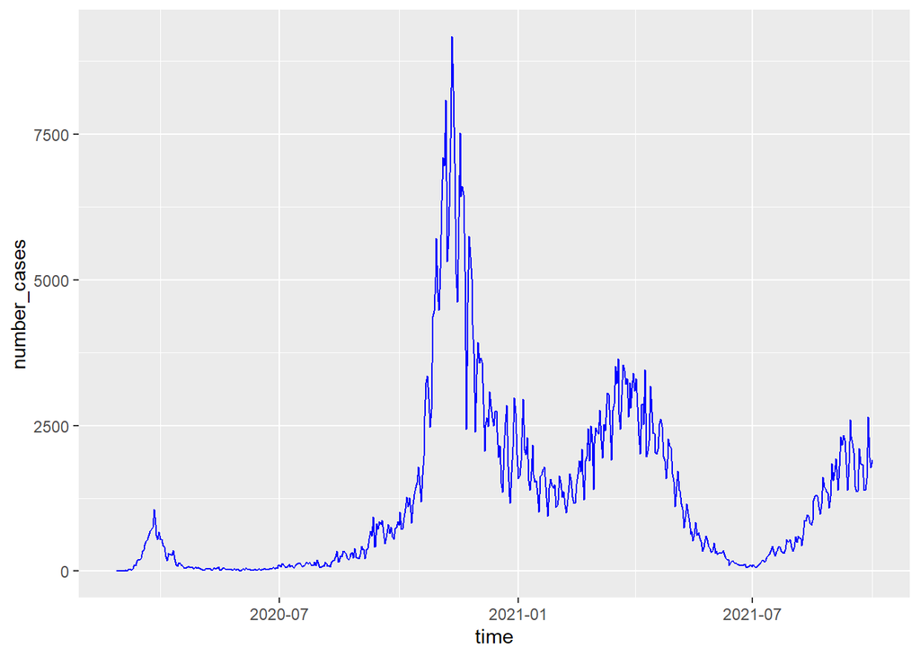

```r
ggplot( data = covid_austria ) +
  geom_line( mapping = aes( x = time, y = number_cases ), color = "blue" )
```

We can even give a title and change the name of the axes in the figure.

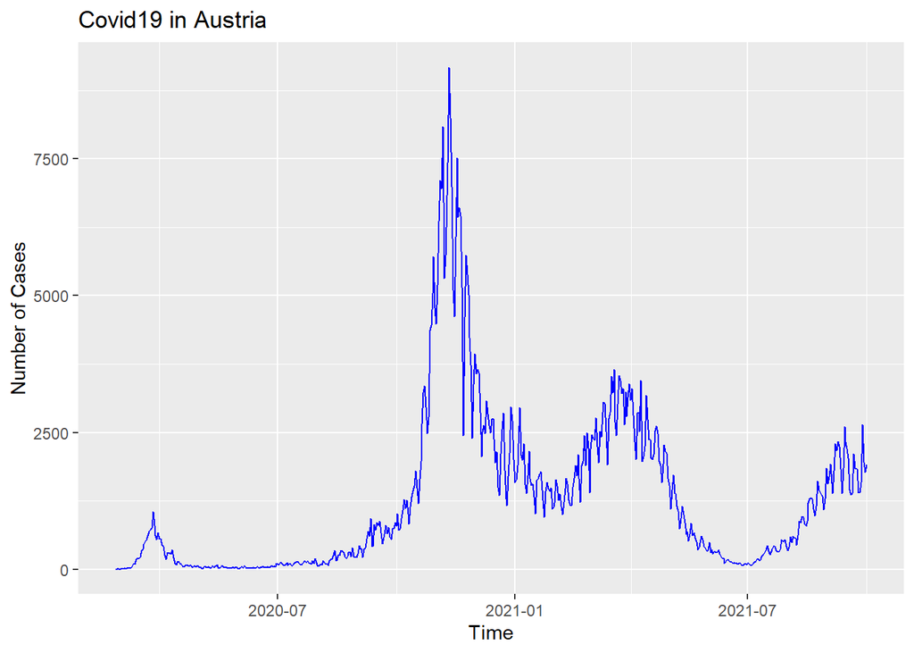

```r
ggplot( data = covid_austria ) +
  geom_line( mapping = aes(x = time, y = number_cases), color = "blue" ) +
  ggtitle( "Covid19 in Austria" ) +
  xlab( "Time" ) +
  ylab( "Number of Cases" )
```

We can even delete the name of x-axis, add a function `labs` which includes axes and title only in one line and a function `scale_x_date` which allows us to mention the other times than dates (in our case we use a break of 2 months and abbreviated months name).

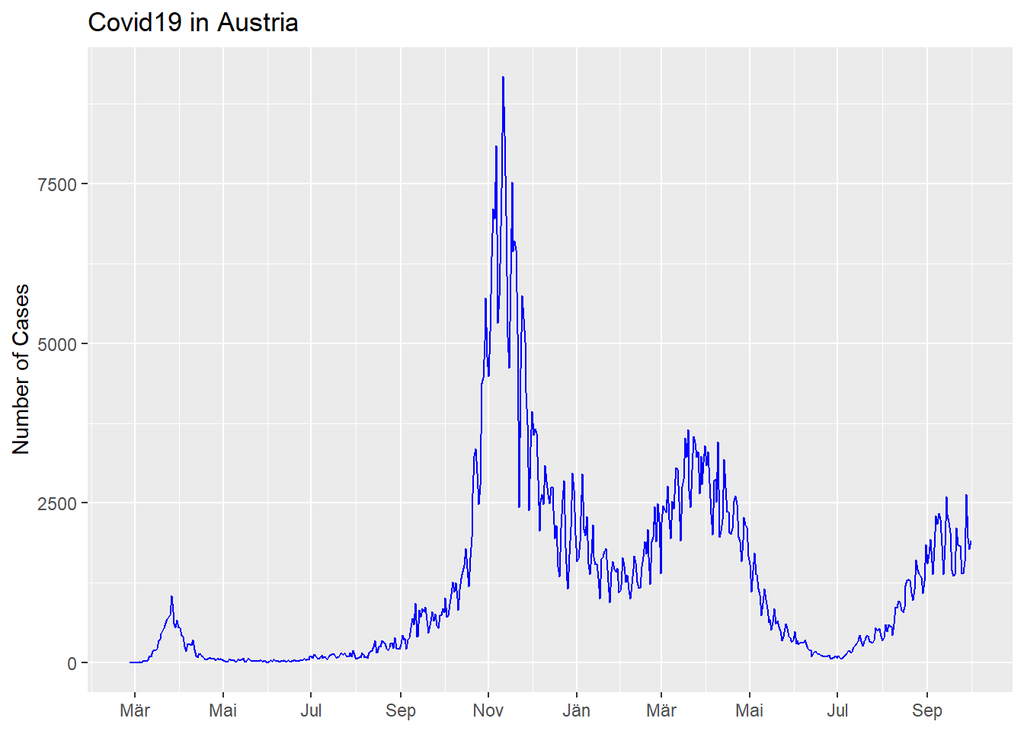

```r
ggplot( data = covid_austria ) +
  geom_line( mapping = aes(x = time, y = number_cases), color = "blue" ) +
  labs( x = NULL, y = "Number of Cases", title = "Covid19 in Austria" ) +
  scale_x_date(date_breaks = "2 month", date_labels = "%b")
```

Here is a line graph of seven days incidence in Austria:

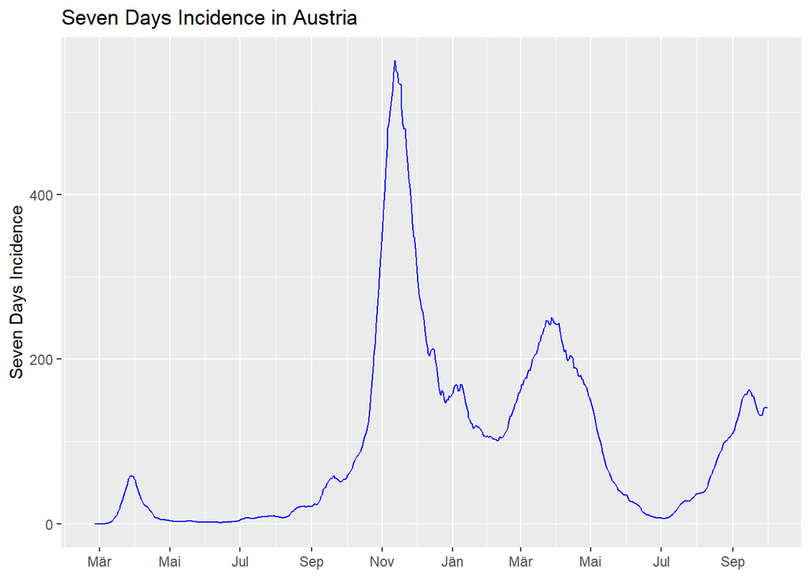

```r
ggplot( data = covid_austria ) +
  geom_line( mapping = aes(x = time, y = seven_days_incidence), color = "blue" ) +
  labs( x = NULL, y = "Seven Days Incidence", title = "Seven Days Incidence in Austria" ) +
  scale_x_date(date_breaks = "2 month", date_labels = "%b")
```

We can even combine two line graphs in one plane. Here are the line graphs of daily covid cases and daily recoveries.

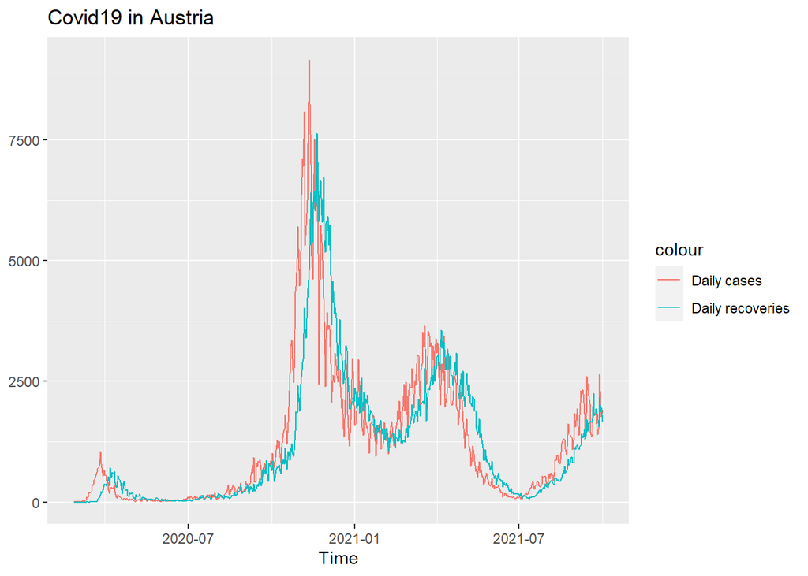

```r
ggplot( data = covid_austria, mapping = aes( x = time ) ) +
  geom_line( mapping = aes(y = number_cases, color = "Daily cases") ) +
  geom_line( mapping = aes(y = daily_recovered, color = "Daily recoveries") ) +
  ggtitle( "Covid19 in Austria" ) +
  xlab( "Time" ) +
  ylab( NULL )
```

We can even draw the bar chart:

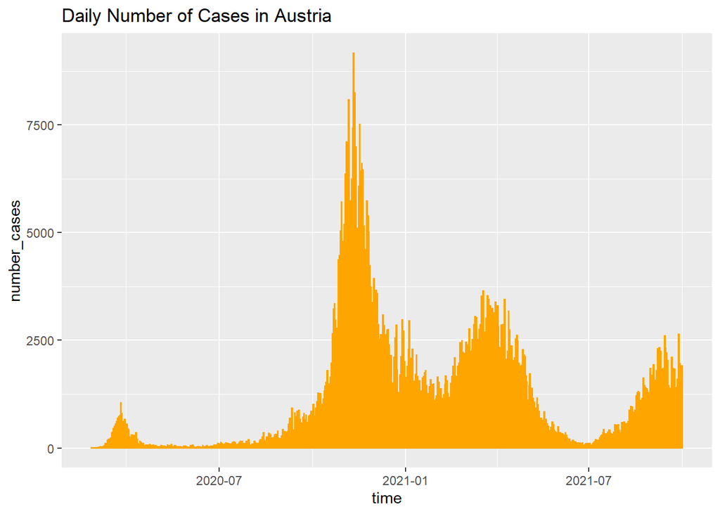

```r
ggplot(data = covid_austria) +
  geom_col(mapping = aes(x = time, y = number_cases), color = "orange") +
  ggtitle("Daily Number of Cases in Austria")
```

Bar chart of daily deaths:

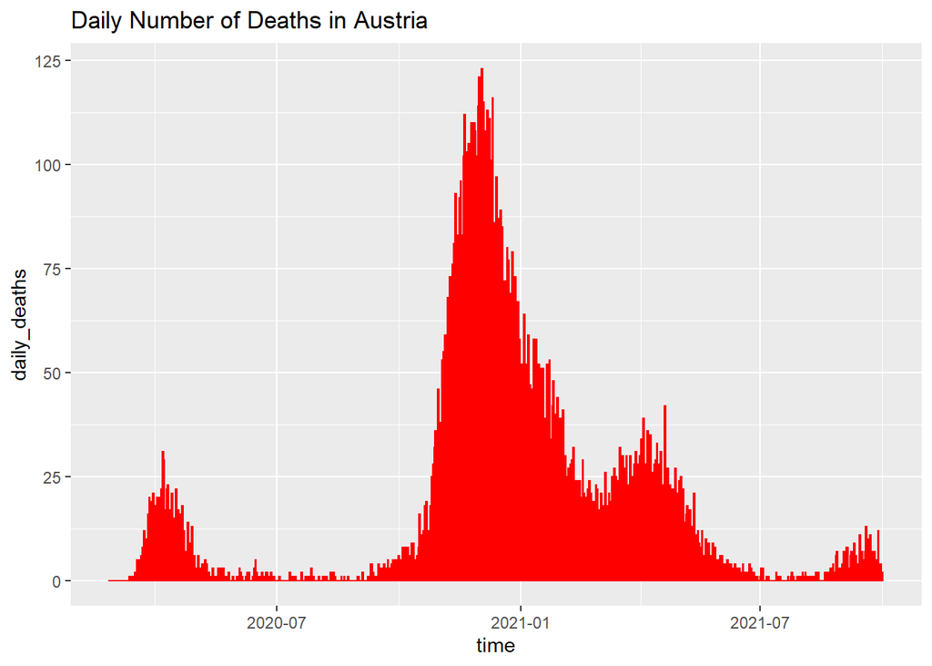

```r
ggplot(data = covid_austria) +
  geom_col(mapping = aes(x = time, y = daily_deaths), color = "red") +
  ggtitle("Daily Number of Deaths in Austria")
```

## The Pipe Operator

From our main data set `covid`, we extracted another data set `covid_austria` in order to analyse data only for Austria. But this can be done without extracting and for this purpose the pipe operator `%>%` is extremely useful which has support from `tidyverse`. Here is some of above examples by using `%>%`.

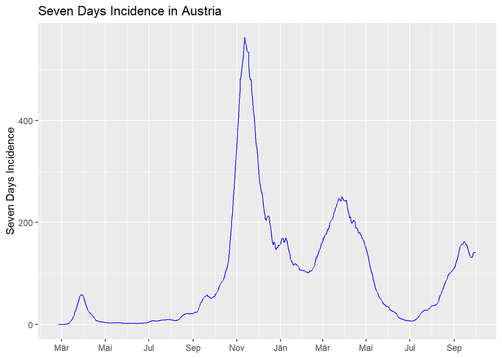

```r
covid %>%
  filter(stateID == 10) %>%
  ggplot() +
  geom_line( mapping = aes(x = time, y = seven_days_incidence), color = "blue" ) +
  labs( x = NULL, y = "Seven Days Incidence", title = "Seven Days Incidence in Austria" ) +
  scale_x_date(date_breaks = "2 month", date_labels = "%b")
```

Daily deaths since March 2021:

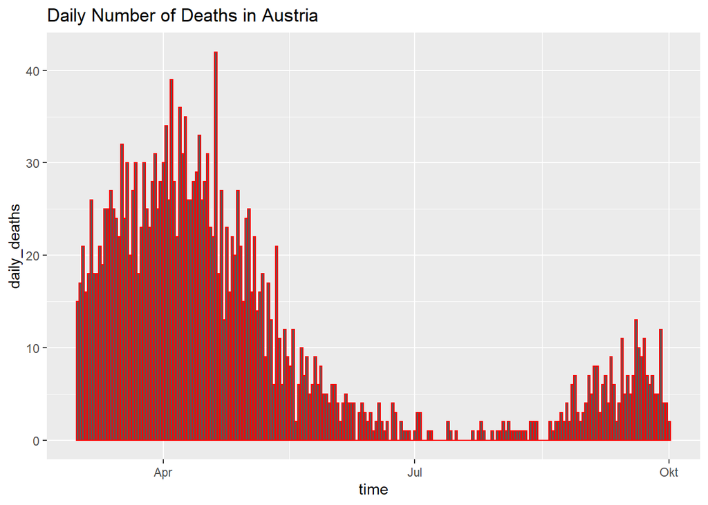

```r
covid %>%
  filter( stateID == 10, time >= "2021-03-01" ) %>%
  ggplot() +
  geom_col(mapping = aes(x = time, y = daily_deaths), color = "red") +
  ggtitle("Daily Number of Deaths in Austria")
```

Let us do now an analysis of all the states of Austria.

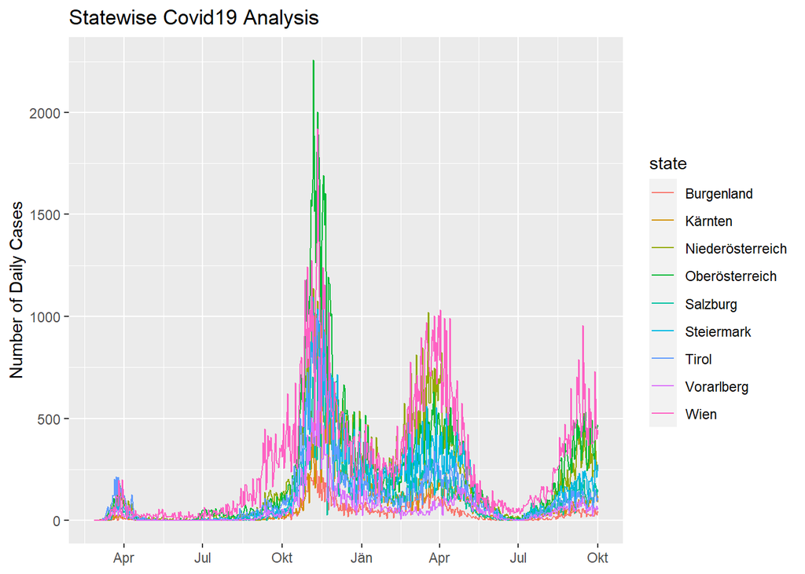

```r
covid %>%
  filter(stateID != 10) %>%
  ggplot() +
  geom_line( mapping = aes(x = time, y = number_cases, color = state) ) +
  labs( x = NULL, y = "Number of Daily Cases", title = "Statewise Covid19 Analysis" ) +
  scale_x_date(date_breaks = "3 month", date_labels = "%b")
```

Seven days incidence in Burgenland, Steiermark and Wien.

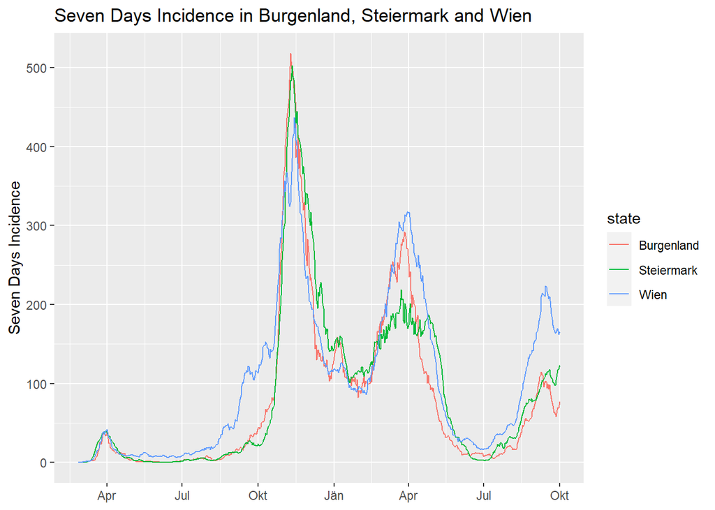

```r
covid %>%
  filter(stateID %in% c(1,  6, 9)) %>%
  ggplot() +
  geom_line( mapping = aes(x = time, y = seven_days_incidence, color = state) ) +
  labs( x = NULL, y = "Seven Days Incidence", title = "Seven Days Incidence in Burgenland, Steiermark and Wien" ) +
  scale_x_date(date_breaks = "3 month", date_labels = "%b")
```

By using the function `facet_wrap` we can also view each layer of every State.

[figure not shown]

[output not shown]

[figure not shown]

```r
covid %>%
  filter(stateID != 10) %>%
  ggplot() +
  geom_line( mapping = aes(x = time, y = seven_days_incidence, color = state) ) +
  labs( x = NULL, y = "Seven Days Incidence", title = "Seven Days Incidence in All States" ) +
  scale_x_date(date_breaks = "3 month", date_labels = "%b") +
  facet_wrap( ~ state, nrow = 3 )
```

*Final note: If you would like to learn more about `tidyverse`, we recommend you to follow the course [Data wrangling in R using the Tidyverse](https://github.com/cbrnr/r_tidyverse) prepared by [Clemens Brunner](https://github.com/cbrnr)*.

See you soon!